# Final Project

John Banta (Project Coordinator), Kelsey Mclnturff, Luping Wang, and Brenna Walters

11/18/2019

## Sections

### Proposal

The United States National Highway Traffic Safety Administration website reports statistics on fatal crashes as part of the Fatality Analysis Reporting System. This dataset is broken into many different tables to emphasize different variables. This dataset is updated yearly to continue informing the US public. Currently, data from years 1994 to 2017 is available. Furthermore, the data can be downloaded in a variety of ways for easy analysis. Nation-wide motor vehicle accidents are a topic of safety that concern both the general public and lawmakers. Statistics through the National Highway Traffic Safety Administration provide the means for insight into what factors influence collisions. These insights could provide awareness for drivers on what factors to be wary of while driving, such as number of passengers, weather conditions, location, time of day, and other variables that the data provide. Communicating the relationships the data reveal can allow drivers to be safer in or avoid conditions that are more prone to accidents. For lawmakers, the same insights could influence traffic laws which increase safety on the road. In addition to influencing traffic laws, the data could provide insight into why current traffic laws are currently in place, such as legal limits for alcohol. The collision data is expansive and lends itself to many angles for analysis. As data exploration and data cleaning progress, we will be able to narrow the scope of analysis and determine the effect a handful of factors have on collision rates. Our goal in analyzing the data is to learn about which factors contribute the most to the number of fatal traffic accidents in the US. Some questions we are interested in answering with the data are:

- During what time period has the highest accident rate?
- What is the relationship between the number of victims and the driver blood alcohol concentration?
- What type of vehicle has the highest rate of collision?
- Who are the people(race, gender, age) who die in these accidents?

Before conducting the analysis, we are going to clean the dataset. We will drop the NAs and relevant columns, eliminate duplicates, and transform the data as needed. Since the data is broken into several different tables, we will need to join several of them together using year as a key. To visualize the data, we will use mainly tables and ggplot. We will use several different types of plots (histograms, barplots, scatterplot matrix, correlation matrix, etc.) to see how variables are distributed and how they relate to the number of fatal accidents. By visualizing the data this way, we hope to see relationships that help us answer the questions listed above.

### Question 2

#### What is the relationship between the number of victims and the driver blood alcohol concentration?

##### Data Cleaning

```r
library(readxl)
#my_data <- read_excel("Alcohol.xls", sheet = "data")
my_data <- read.table(file = "Alcohol.xls",
                      sep = "\t", header=TRUE)
colnames(my_data)
```

```
##  [1] "X"
##  [2] "BAC....00"
##  [3] "X.1"
##  [4] "BAC....01...07"
##  [5] "X.2"
##  [6] "BAC....08."
##  [7] "X.3"
##  [8] "Total"
##  [9] "Total.Fatalities.in.Alcohol..Related.Crashes"
## [10] "X.4"
## [11] "X.5"
```

As you can see above, there are total 11 columns, but they are pretty messy and unreadable. The original table contains the information of different Blood Alcohol Concentration levels from year 1994-2017. I broke it down into 4 different tables based off different BAC levels.

```r
library(dplyr)
Zero_BAC = select(my_data, -4:-11)
Mid_BAC=select(my_data, -2:-3,-6:-11)
High_BAC = select(my_data, -2:-5,-8:-11)
Overall_BAC = select(my_data, -2:-8,-11)

colnames(Zero_BAC)[colnames(Zero_BAC)=="X"] <- "Year"
colnames(Zero_BAC)[colnames(Zero_BAC)=="BAC....00"] <- "Number of Fatalities without Alcohol"
colnames(Zero_BAC)[colnames(Zero_BAC)=="X.1"] <- "Percent"

colnames(Mid_BAC)[colnames(Mid_BAC)=="X"] <- "Year"
colnames(Mid_BAC)[colnames(Mid_BAC)=="BAC....01...07"] <- "Number of Fatalities"
colnames(Mid_BAC)[colnames(Mid_BAC)=="X.2"] <- "Percent"

colnames(High_BAC)[colnames(High_BAC)=="X"] <- "Year"
colnames(High_BAC)[colnames(High_BAC)=="BAC....08."] <- "Number of Fatalities"
colnames(High_BAC)[colnames(High_BAC)=="X.3"] <- "Percent"

colnames(Overall_BAC)[colnames(Overall_BAC)=="X"] <- "Year"
colnames(Overall_BAC)[colnames(Overall_BAC)=="Total.Fatalities.in.Alcohol..Related.Crashes"] <- "Total.Fatalities.in.Alcohol"
colnames(Overall_BAC)[colnames(Overall_BAC)=="X.4"] <- "Percent"

#Drop first row for each table
Zero_BAC = Zero_BAC[-1,]
Mid_BAC = Mid_BAC[-1,]
High_BAC= High_BAC[-1,]
Overall_BAC=Overall_BAC[-1,]

head(Zero_BAC)
```

```
##   Year Number of Fatalities without Alcohol Percent
## 2 1994                                 2717      64
## 3 1995                                 2661      63
## 4 1996                                 2588      65
## 5 1997                                 2537      69
## 6 1998                                 2348      67
## 7 1999                                 2397      67
```

```r
head(Mid_BAC)
```

```
##   Year Number of Fatalities Percent
## 2 1994                  254       6
## 3 1995                  291       7
## 4 1996                  278       7
## 5 1997                  219       6
## 6 1998                  216       6
## 7 1999                  220       6
```

```r
head(High_BAC)
```

```
##   Year Number of Fatalities Percent
## 2 1994                 1245      29
## 3 1995                 1217      29
## 4 1996                 1107      28
## 5 1997                  914      25
## 6 1998                  921      26
## 7 1999                  926      26
```

```r
head(Overall_BAC)
```

```
##   Year Total.Fatalities.in.Alcohol Percent
## 2 1994                        1499      35
## 3 1995                        1509      36
## 4 1996                        1385      35
## 5 1997                        1132      31
## 6 1998                        1137      33
## 7 1999                        1146      32
```

##### Data Exploration

The number of fatalities is already collected and summaried in the original dataset, which means each year has a corresponding data point/value. I found it’s not feasible for me to make line plot,bar plot and pie chart. So I did the scatter plot. In order to make good comparsion between Number of Fatalities without Alcohol and Total Fatalities in Alcohol, I set the same y-axis(100-3000) ranges for both plots.

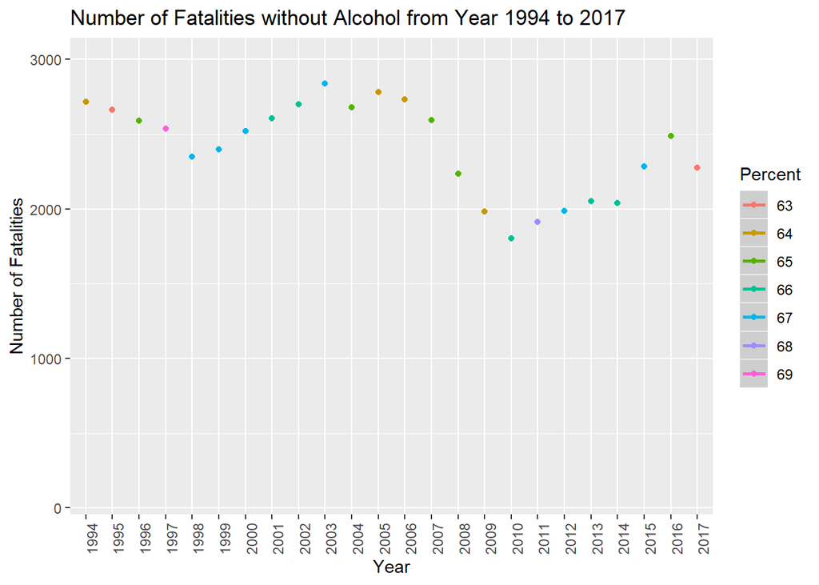

```r
library(ggplot2)
ggplot(Zero_BAC, aes(x=Year, y=as.numeric(as.character(`Number of Fatalities without Alcohol`)), color=Percent))+ylim(100,3000)+geom_smooth()+geom_point()+theme(axis.text.x = element_text(angle = 90, hjust = 1))+labs(title="Number of Fatalities without Alcohol from Year 1994 to 2017", y = "Number of Fatalities")
```

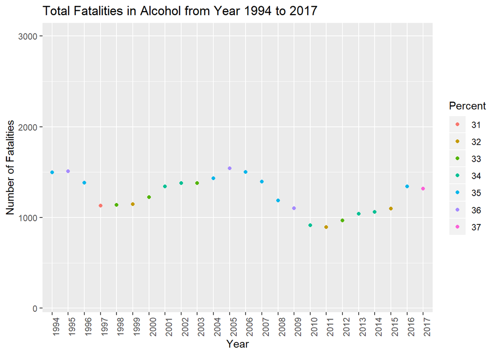

```r
ggplot(Overall_BAC, aes(x=Year, y=as.numeric(as.character(`Total.Fatalities.in.Alcohol`)), color=Percent))+ylim(100,3000) +geom_point()+theme(axis.text.x = element_text(angle = 90, hjust = 1))+labs(title="Total Fatalities in Alcohol from Year 1994 to 2017",y = "Number of Fatalities")
```

I looked into the relationships between different levels of BAC and number of fatalities. Same here, I use the same y-axis ranges(100-1300) for both plots.

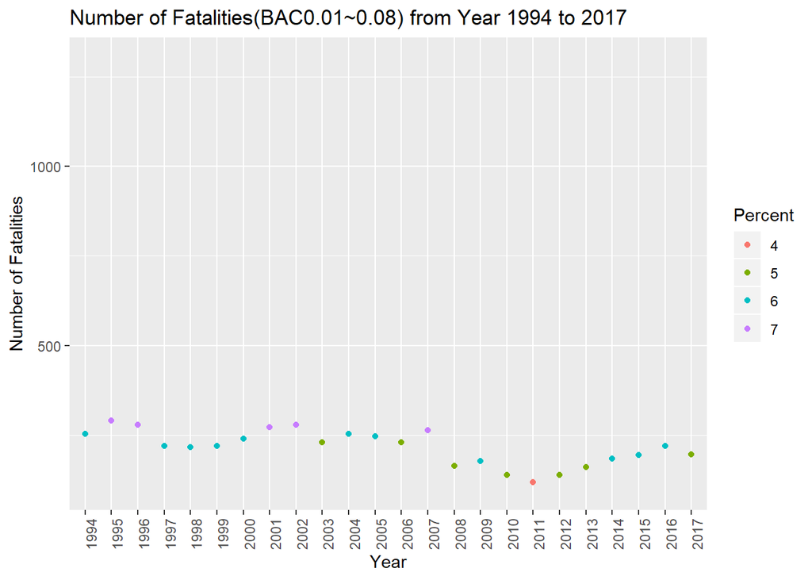

```r
ggplot(Mid_BAC, aes(x=Year, y=as.numeric(as.character(`Number of Fatalities`)), color=Percent))+ylim(100,1300)+geom_point() + theme(axis.text.x = element_text(angle = 90, hjust = 1))+labs(title="Number of Fatalities(BAC0.01~0.08) from Year 1994 to 2017", y = "Number of Fatalities")
```

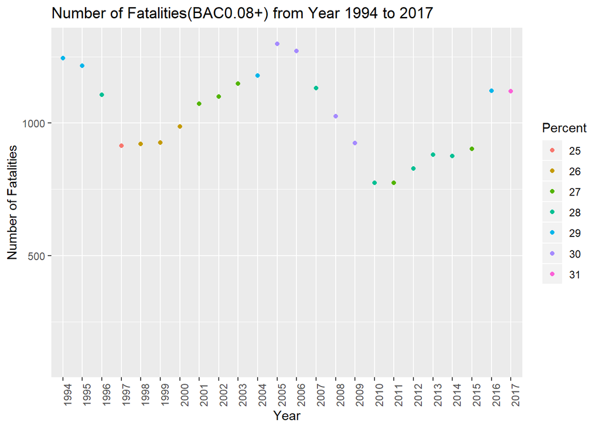

```r
ggplot(High_BAC, aes(x=Year, y=as.numeric(as.character(`Number of Fatalities`)), color=Percent))+ylim(100,1300)+geom_point()+ theme(axis.text.x = element_text(angle = 90, hjust = 1))+labs(title="Number of Fatalities(BAC0.08+) from Year 1994 to 2017" , y = "Number of Fatalities")
```

##### Challenges

I had plotting the data pionts in ggplot in the beginning. At frist I wrote: ggplot(Zero_BAC, aes(x=Year, y=`Number of Fatalities without Alcohol`, color=Percent))+ylim(100,3000)+geom_point()+theme(axis.text.x = element_text(angle = 90, hjust = 1))+labs(title=“Number of Fatalities without Alcohol from Year 1994 to 2017”, y = “Number of Fatalities”)

It gives an error “Error: Discrete value supplied to continuous scale”. And then, I found I need to make the “y” as charater and then transform it into numercial value: **y=as.numeric(as.character(`Number of Fatalities without Alcohol`))**

##### Citations

https://stackoverflow.com/questions/29278153/plotting-with-ggplot2-error-discrete-value-supplied-to-continuous-scale-on-c

### Question 3

#### What type of vehicle has the highest rate of collision? How is the vehicle type related to the number of victims?

##### Data Cleaning

For my data cleaning, I had to change the column names because there were the same name of columns for the different types of vehicles involved in the accidents. Hence, I just added the vehicle type to the corresponding column names to get the following column names. After I was done with that, I saved the file as a csv so that I could easily import it into r. I then renamed them to be a little more usable

```r
type<-read.csv(file = 'Traffic2.csv')
colnames(type)
```

```
##  [1] "ï..Year"
##  [2] "Number.of.Passenger.Cars"
##  [3] "Passenger.Cars.Involvement.Rate.per.100.Million.VMT"
##  [4] "Passenger.Cars.Involvement.Rate.per.100.000.Registered.Vehicles"
##  [5] "Number.of.Light.Trucks"
##  [6] "Light.Trucks.Involvement.Rate.per.100.Million.VMT1"
##  [7] "Light.Trucks.Involvement.Rate.per.100.000.Registered.Vehicles1"
##  [8] "Number.of.Large.Trucks"
##  [9] "Large.Trucks.Involvement.Rate.per.100.Million.VMT2"
## [10] "Large.Trucks.Involvement.Rate.per.100.000.Registered.Vehicles2"
## [11] "Number.of.Motorcycles"
## [12] "Motorcycles.Involvement.Rate.per.100.Million.VMT3"
## [13] "Motorcycles.Involvement.Rate.per.100.000.Registered.Vehicles3"
```

```r
names(type)<-c("Year","Num_PV", "PV_per_100M", "PV_per_100k_RV","Num_LiT", "LiT_per_100M", "LiT_per_100k_RV","Num_LT", "LT_per_100M", "LT_per_100k_RV","Num_MC", "MC_per_100M", "MC_per_100k_RV")
colnames(type)
```

```
##  [1] "Year"            "Num_PV"          "PV_per_100M"
##  [4] "PV_per_100k_RV"  "Num_LiT"         "LiT_per_100M"
##  [7] "LiT_per_100k_RV" "Num_LT"          "LT_per_100M"
## [10] "LT_per_100k_RV"  "Num_MC"          "MC_per_100M"
## [13] "MC_per_100k_RV"
```

##### Data Exploration

So first I will look at the just the numbers of the different statistics across vehicle types.

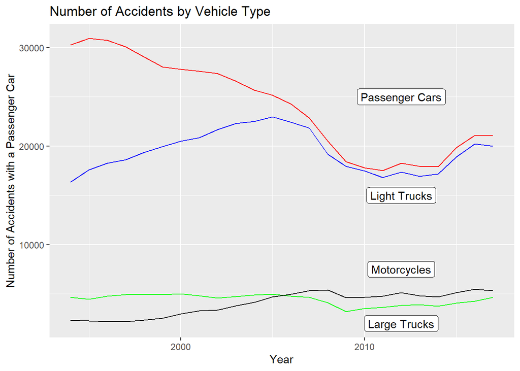

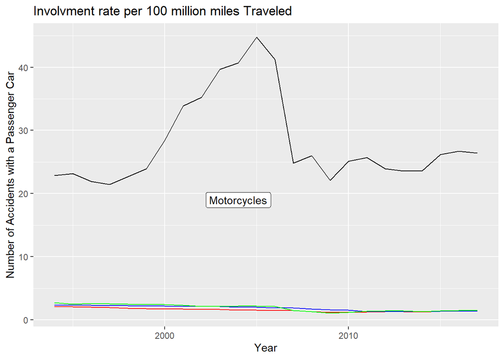

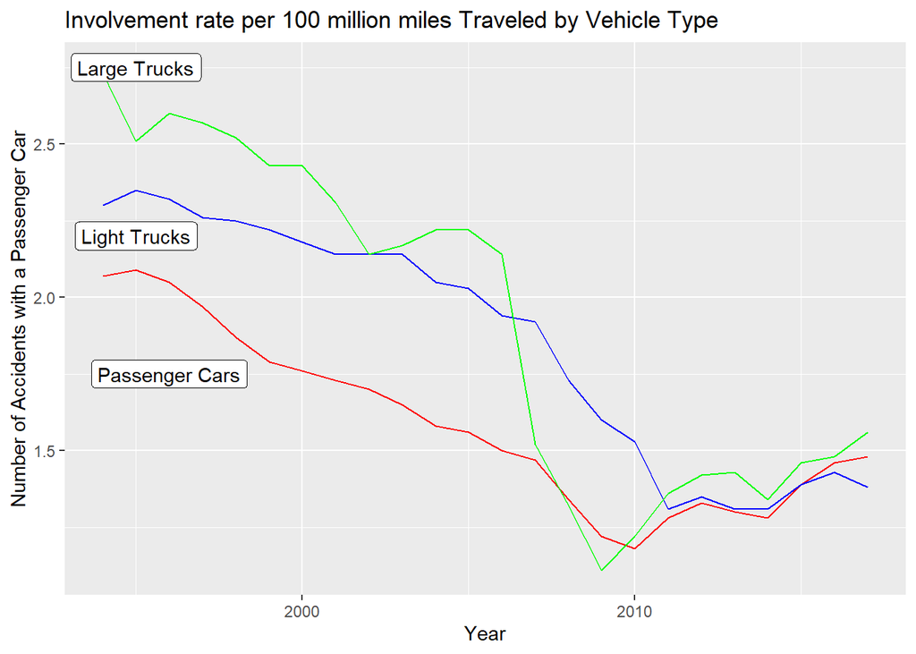

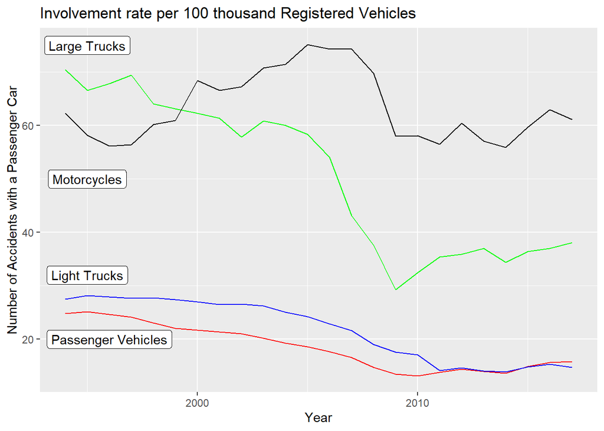

```r
Occupant<-read.csv("Traffic3.csv")
colnames(Occupant)
```

```
## [1] "ï..Year"                  "Passenger.Cars.Occupants"
## [3] "Light.Trucks.Occupants"   "Large.Trucks.Occupants"
## [5] "Motorcycle.Occupants"     "Buses"
## [7] "Other..Unknown"           "Total"
```

```r
names(Occupant)<-c("Year","PV_Occupants", "LiT_Occupants", "LT_Occupants", "MC_Occupants", "Buses_Occupants", "Other", "Total")
colnames(Occupant)
```

```
## [1] "Year"            "PV_Occupants"    "LiT_Occupants"   "LT_Occupants"
## [5] "MC_Occupants"    "Buses_Occupants" "Other"           "Total"
```

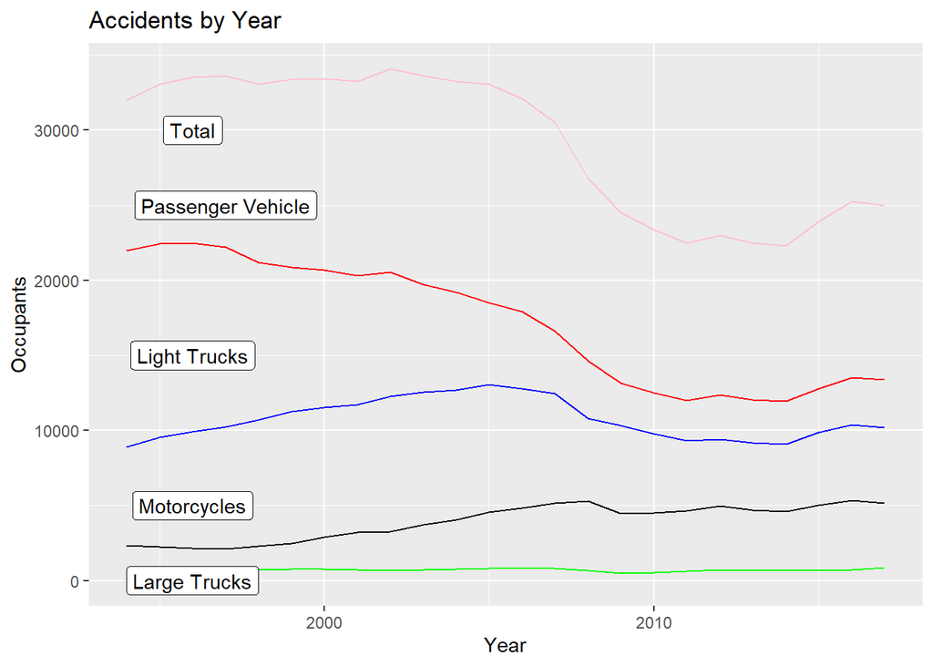

##### Conclusions

Looking at the above graphs, it appears that while there are fewer accidents including motorcycles by number alone. However when accounting for the smaller amount of motorcycles, it appears that they get into accidents at a higher rate. This could be due to the fact that they are much smaller than other motor vehicles and hence do not get seen as easily as other motor vehicles. On the other side passenger vehicles have the most total number of accidents every year, however the involvement rate is consistently one of the lowest ones.

##### Challenges

With the format of the data I didn’t forsee a way to easily add a legend so I added labels to differentiate and kept the same colors throughout in order to help avoid confusion.

##### Citations

https://stackoverflow.com/questions/44012554/r-how-can-i-annotate-a-ggplot-with-a-text-box/44012702

### Question 4

#### Who are the people(race, gender, age) who die in these accidents?

**Libraries**

```r
library(readxl)
library(ggplot2)
library(tidyverse)
```

**1. Gender** One of the demographics I wanted to look into was gender. I loaded a table with information on total fatalities grouped by gender - which had levels: “Male”, “Female”, “Unknown”, and “Total”. The only cleaning I did was eliminate an empty column and drop the “Total” and “Unknown” categories from the gender column.

```r
#Load data
gender = read.table('Gender.xls', sep = '\t', header = TRUE)
head(gender)
```

```
##   FieldDesc Total  X
## 1      Male 26380 NA
## 2    Female 10697 NA
## 3   Unknown    56 NA
## 4     Total 37133 NA
```

```r
#drop empty NA column
gender = gender[-3]
#Narrow down to just male and female
gender$FieldDesc = droplevels(gender$FieldDesc, exclude= c("Total","Unknown"))
gender = na.omit(gender)
head(gender)
```

```
##   FieldDesc Total
## 1      Male 26380
## 2    Female 10697
```

Visualization

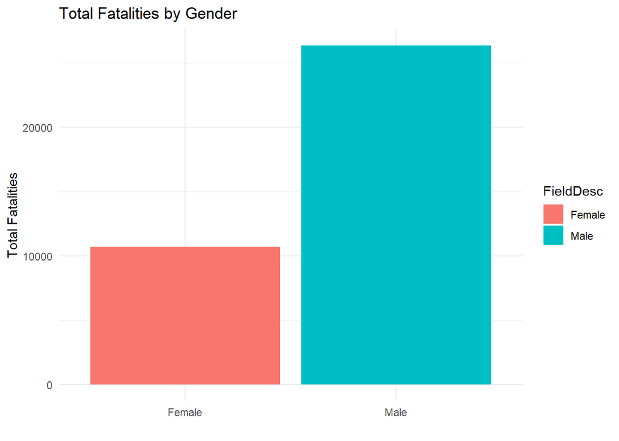

```r
ggplot(gender, aes(FieldDesc, Total, fill=FieldDesc)) +
  geom_bar(stat="Identity") +
  theme_minimal() +
  labs(title="Total Fatalities by Gender", x="", y="Total Fatalities")
```

From the plot, we can see that fatalities for men are more than double that of women. There are likely many reasons for this result. In order to break this down further, I would look into other tables involving gender. Tables on the gender and driver status of all fatalities or gender ratios over time, for example, might provide further insight as to why there are more male fatalities; however, I was not able to cover that in this analysis.

**2. Age ranges**

In order to take a look at age ranges, I loaded tables for all years(1994-2017) which included fatalities grouped by age.

```r
#Load tables
Age1994 = read.table('Age1994.xls', sep = '\t', header = TRUE)
Age1995 = read.table('Age1995.xls', sep = '\t', header = TRUE)
Age1996 = read.table('Age1996.xls', sep = '\t', header = TRUE)
Age1997 = read.table('Age1997.xls', sep = '\t', header = TRUE)
Age1998 = read.table('Age1998.xls', sep = '\t', header = TRUE)
Age1999 = read.table('Age1999.xls', sep = '\t', header = TRUE)
Age2000 = read.table('Age2000.xls', sep = '\t', header = TRUE)
Age2001 = read.table('Age2001.xls', sep = '\t', header = TRUE)
Age2002 = read.table('Age2002.xls', sep = '\t', header = TRUE)
Age2003 = read.table('Age2003.xls', sep = '\t', header = TRUE)
Age2004 = read.table('Age2004.xls', sep = '\t', header = TRUE)
Age2005 = read.table('Age2005.xls', sep = '\t', header = TRUE)
Age2006 = read.table('Age2006.xls', sep = '\t', header = TRUE)
Age2007 = read.table('Age2007.xls', sep = '\t', header = TRUE)
Age2008 = read.table('Age2008.xls', sep = '\t', header = TRUE)
Age2009 = read.table('Age2009.xls', sep = '\t', header = TRUE)
Age2010 = read.table('Age2010.xls', sep = '\t', header = TRUE)
Age2011 = read.table('Age2011.xls', sep = '\t', header = TRUE)
Age2012 = read.table('Age2012.xls', sep = '\t', header = TRUE)
Age2013 = read.table('Age2013.xls', sep = '\t', header = TRUE)
Age2014 = read.table('Age2014.xls', sep = '\t', header = TRUE)
Age2015 = read.table('Age2015.xls', sep = '\t', header = TRUE)
Age2016 = read.table('Age2016.xls', sep = '\t', header = TRUE)
Age2017 = read.table('Age2017.xls', sep = '\t', header = TRUE)
```

Before merging all the data frames, I removed empty columns and renamed the variables to specify the year.

```r
#Rename columns and remove empty columns
Age1994 = Age1994[-3]
names(Age1994) = c("Age","Killed1994")
Age1995 = Age1995[-3]
names(Age1995) = c("Age","Killed1995")
Age1996 = Age1996[-3]
names(Age1996) = c("Age","Killed1996")
Age1997 = Age1997[-3]
names(Age1997) = c("Age","Killed1997")
Age1998 = Age1998[-3]
names(Age1998) = c("Age","Killed1998")
Age1999 = Age1999[-3]
names(Age1999) = c("Age","Killed1999")
Age2000 = Age2000[-3]
names(Age2000) = c("Age","Killed2000")
Age2001 = Age2001[-3]
names(Age2001) = c("Age","Killed2001")
Age2002 = Age2002[-3]
names(Age2002) = c("Age","Killed2002")
Age2003 = Age2003[-3]
names(Age2003) = c("Age","Killed2003")
Age2004 = Age2004[-3]
names(Age2004) = c("Age","Killed2004")
Age2005 = Age2005[-3]
names(Age2005) = c("Age","Killed2005")
Age2006 = Age2006[-3]
names(Age2006) = c("Age","Killed2006")
Age2007 = Age2007[-3]
names(Age2007) = c("Age","Killed2007")
Age2008 = Age2008[-3]
names(Age2008) = c("Age","Killed2008")
Age2009 = Age2009[-3]
names(Age2009) = c("Age","Killed2009")
Age2010 = Age2010[-3]
names(Age2010) = c("Age","Killed2010")
Age2011 = Age2011[-3]
names(Age2011) = c("Age","Killed2011")
Age2012 = Age2012[-3]
names(Age2012) = c("Age","Killed2012")
Age2013 = Age2013[-3]
names(Age2013) = c("Age","Killed2013")
Age2014 = Age2014[-3]
names(Age2014) = c("Age","Killed2014")
Age2015 = Age2015[-3]
names(Age2015) = c("Age","Killed2015")
Age2016 = Age2016[-3]
names(Age2016) = c("Age","Killed2016")
Age2017 = Age2017[-3]
names(Age2017) = c("Age","Killed2017")
```